# Ejercicio 1: perfil químico de vinos (clustering + PCA)

SESIÓN 18 — APRENDIZAJE NO SUPERVISADO

Autor/a

Jorge Juvenal Campos Ferreira — TC2001B.601

Fecha de publicación

24 de mayo de 2026

```r
options(scipen = 999)
```

Idea central de esta sesión:

En el aprendizaje NO supervisado NO existe una variable objetivo (una “y” que queramos predecir). Por eso aquí NO partimos los datos en entrenamiento/prueba: no hay un acierto que medir. El objetivo es DESCUBRIR estructura: ¿las muestras de vino se agrupan en perfiles químicos naturales? ¿cuántos grupos hay y qué los distingue?

Trabajaremos dos familias de técnicas:

- PCA (análisis de componentes principales): reduce las 11 variables a unos pocos ejes que concentran la varianza; sirve para visualizar y entender qué variables “se mueven juntas”.
- Clustering (k-means y jerárquico): agrupa las observaciones por cercanía. El alumno decide cuántos grupos usar con el codo y la silueta.

```r
# Librerías ----
library(tidyverse)
library(tidymodels)
library(factoextra)
library(cluster)
```

```r
tidymodels::tidymodels_prefer()
```

## 1. CARGA Y PREPARACIÓN DE LOS DATOS

```r
# Cargamos las 600 muestras. Todas las columnas son atributos
# fisicoquímicos: no hay columna id ni variable objetivo que remover.
vinos <- read_csv("datos.csv")
```

```r
# Inspección rápida: dimensiones, tipos y faltantes.
glimpse(vinos)
```

```
Rows: 600
Columns: 11
$ acidez_fija          <dbl> 6.2536, 5.9861, 8.7691, 8.8989, 7.3055, 6.4908, 5…
$ acidez_volatil       <dbl> 0.3322, 0.2392, 0.7486, 0.4001, 0.3657, 0.5884, 0…
$ acido_citrico        <dbl> 0.4503, 0.4231, 0.0670, -0.0903, 0.2678, 0.4563, …
$ azucar_residual      <dbl> 2.3408, 7.1028, 3.5495, 4.4901, 9.2620, 2.2220, 7…
$ cloruros             <dbl> 0.0486, 0.0217, 0.0801, 0.0876, 0.0554, 0.0662, 0…
$ dioxido_azufre_libre <dbl> 30.9692, 39.6832, 7.1888, 6.3257, 43.4406, 39.112…
$ dioxido_azufre_total <dbl> 112.2979, 157.8532, 40.6250, 43.8776, 134.5487, 1…
$ densidad             <dbl> 0.9939, 0.9966, 0.9982, 0.9979, 0.9946, 0.9968, 0…
$ ph                   <dbl> 3.3146, 3.3961, 3.1319, 3.3340, 3.4065, 3.3054, 3…
$ sulfatos             <dbl> 0.5919, 0.4582, 0.5016, 0.4689, 0.7760, 0.6851, 0…
$ alcohol              <dbl> 10.3862, 9.3331, 9.4140, 10.4421, 10.1377, 11.705…
```

```r
summary(vinos)
```

```
  acidez_fija     acidez_volatil    acido_citrico     azucar_residual
 Min.   : 4.514   Min.   :-0.1289   Min.   :-0.2498   Min.   :-1.841
 1st Qu.: 6.509   1st Qu.: 0.2521   1st Qu.: 0.1514   1st Qu.: 1.873
 Median : 7.229   Median : 0.3669   Median : 0.3134   Median : 2.944
 Mean   : 7.332   Mean   : 0.3750   Mean   : 0.2896   Mean   : 3.944
 3rd Qu.: 8.103   3rd Qu.: 0.4886   3rd Qu.: 0.4180   3rd Qu.: 6.801
 Max.   :10.200   Max.   : 0.8934   Max.   : 0.7042   Max.   :10.383
    cloruros       dioxido_azufre_libre dioxido_azufre_total    densidad
 Min.   :0.00810   Min.   : 2.778       Min.   : 22.28       Min.   :0.9898
 1st Qu.:0.04188   1st Qu.:19.549       1st Qu.: 78.97       1st Qu.:0.9941
 Median :0.05675   Median :28.457       Median :110.18       Median :0.9957
 Mean   :0.05983   Mean   :29.350       Mean   :110.90       Mean   :0.9956
 3rd Qu.:0.07702   3rd Qu.:39.394       3rd Qu.:143.13       3rd Qu.:0.9970
 Max.   :0.12400   Max.   :59.229       Max.   :209.61       Max.   :1.0026
       ph           sulfatos         alcohol
 Min.   :2.842   Min.   :0.1293   Min.   : 7.556
 1st Qu.:3.147   1st Qu.:0.4988   1st Qu.: 9.930
 Median :3.236   Median :0.5807   Median :10.618
 Mean   :3.240   Mean   :0.5824   Mean   :10.635
 3rd Qu.:3.331   3rd Qu.:0.6725   3rd Qu.:11.382
 Max.   :3.761   Max.   :0.9847   Max.   :13.072
```

```r
# ¿Cuántos NAs hay por columna? En este dataset no hay, pero verificarlo
# siempre es parte del flujo: los algoritmos de distancia no toleran NAs.
colSums(is.na(vinos))
```

```
         acidez_fija       acidez_volatil        acido_citrico
                   0                    0                    0
     azucar_residual             cloruros dioxido_azufre_libre
                   0                    0                    0
dioxido_azufre_total             densidad                   ph
                   0                    0                    0
            sulfatos              alcohol
                   0                    0
```

```r
# Antes de normalizar, miremos la colinealidad. dioxido_azufre_total
# contiene al libre (total = libre + combinado), así que esperamos una
# correlación muy alta entre ambos. No la eliminamos: el PCA la absorberá
# proyectando sobre ejes ortogonales, pero conviene tenerla presente al
# interpretar las cargas.
matriz_cor <- vinos %>%
  cor() %>%
  round(2)
matriz_cor[, c("dioxido_azufre_libre", "dioxido_azufre_total")]
```

```
                     dioxido_azufre_libre dioxido_azufre_total
acidez_fija                         -0.57                -0.55
acidez_volatil                      -0.55                -0.54
acido_citrico                        0.61                 0.61
azucar_residual                      0.67                 0.66
cloruros                            -0.52                -0.51
dioxido_azufre_libre                 1.00                 0.98
dioxido_azufre_total                 0.98                 1.00
densidad                            -0.22                -0.22
ph                                   0.11                 0.11
sulfatos                            -0.15                -0.15
alcohol                              0.20                 0.20
```

¿POR QUÉ NORMALIZAR (z-score) ES INDISPENSABLE AQUÍ?

Las variables están en escalas muy distintas: cloruros y ácido cítrico valen menos de 1, mientras que dioxido_azufre_total llega a cientos. Tanto el PCA (que maximiza varianza) como el clustering (que mide distancias) son SENSIBLES A LA ESCALA. Sin normalizar, el dióxido de azufre total dominaría por completo la varianza y las distancias, y los grupos reflejarían solo las unidades de medida, no la química real. La normalización z-score deja cada variable con media 0 y desviación 1, de modo que todas pesan por igual.

```r
# Construimos un recipe SOLO para preprocesar (no hay modelo supervisado).
# step_impute_median: red de seguridad si hubiera NAs (aquí no cambia nada).
# step_normalize: z-score sobre todas las variables numéricas.
receta_vinos <- recipe(~ ., data = vinos) %>%
  step_impute_median(all_numeric_predictors()) %>%
  step_normalize(all_numeric_predictors())
```

```r
# prep() aprende las medianas y los parámetros de escala; bake() devuelve
# la matriz ya normalizada y lista para PCA y clustering.
vinos_norm <- receta_vinos %>%
  prep() %>%
  bake(new_data = NULL)
```

```r
# Verificación: cada columna debe tener media ~0 y desviación ~1.
vinos_norm %>%
  summarise(across(everything(), list(media = mean, desv = sd))) %>%
  glimpse()
```

```
Rows: 1
Columns: 22
$ acidez_fija_media          <dbl> 0.000000000000002715606
$ acidez_fija_desv           <dbl> 1
$ acidez_volatil_media       <dbl> -0.00000000000000149362
$ acidez_volatil_desv        <dbl> 1
$ acido_citrico_media        <dbl> 0.000000000000001102451
$ acido_citrico_desv         <dbl> 1
$ azucar_residual_media      <dbl> -0.0000000000000002420286
$ azucar_residual_desv       <dbl> 1
$ cloruros_media             <dbl> -0.000000000000001445788
$ cloruros_desv              <dbl> 1
$ dioxido_azufre_libre_media <dbl> -0.000000000000002703486
$ dioxido_azufre_libre_desv  <dbl> 1
$ dioxido_azufre_total_media <dbl> -0.000000000000001140662
$ dioxido_azufre_total_desv  <dbl> 1
$ densidad_media             <dbl> 0.0000000000000222992
$ densidad_desv              <dbl> 1
$ ph_media                   <dbl> -0.000000000000005245434
$ ph_desv                    <dbl> 1
$ sulfatos_media             <dbl> 0.0000000000000002612725
$ sulfatos_desv              <dbl> 1
$ alcohol_media              <dbl> 0.000000000000001871836
$ alcohol_desv               <dbl> 1
```

## 2. PCA — ANÁLISIS DE COMPONENTES PRINCIPALES

El PCA reexpresa las 11 variables en 11 nuevos ejes (componentes) que son combinaciones lineales de las originales, ordenados de mayor a menor varianza explicada. Las primeras componentes resumen lo esencial de la variabilidad; nos permiten visualizar 600 vinos en un plano (PC1-PC2). Como ya normalizamos, NO volvemos a escalar dentro de prcomp().

```r
pca_vinos <- prcomp(vinos_norm, center = FALSE, scale. = FALSE)
```

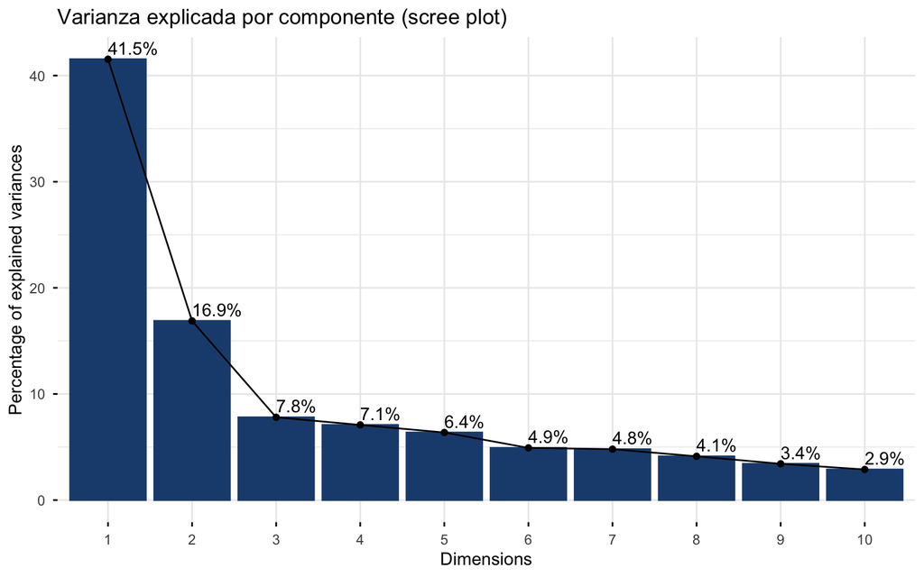

```r
# Scree plot: porcentaje de varianza explicada por cada componente.
# Se lee buscando el "codo": el punto a partir del cual añadir componentes
# aporta poco. Ahí decidimos cuántas componentes retener.
fviz_eig(pca_vinos, addlabels = TRUE,
         barfill = "#1e4c7d", barcolor = "#1e4c7d",
         main = "Varianza explicada por componente (scree plot)")
```

```r
# Varianza explicada en números (acumulada incluida).
varianza_explicada <- summary(pca_vinos)$importance
varianza_explicada[, 1:5]
```

```
                           PC1      PC2       PC3       PC4       PC5
Standard deviation     2.13771 1.362861 0.9262815 0.8827186 0.8370327
Proportion of Variance 0.41544 0.168850 0.0780000 0.0708400 0.0636900
Cumulative Proportion  0.41544 0.584290 0.6622900 0.7331300 0.7968200
```

```r
# Cargas (rotation): cuánto pesa cada variable original en cada componente.
# Aquí interpretamos QUÉ representan PC1 y PC2 según sus cargas.
cargas <- pca_vinos$rotation[, 1:2] %>%
  round(2)
cargas
```

```
                       PC1   PC2
acidez_fija           0.34  0.01
acidez_volatil        0.34  0.08
acido_citrico        -0.37 -0.08
azucar_residual      -0.27  0.48
cloruros              0.35  0.22
dioxido_azufre_libre -0.41  0.24
dioxido_azufre_total -0.41  0.23
densidad              0.20  0.32
ph                   -0.13 -0.33
sulfatos              0.03 -0.44
alcohol              -0.20 -0.44
```

INTERPRETACIÓN DE LAS PRIMERAS COMPONENTES (leer las cargas de ‘cargas’):

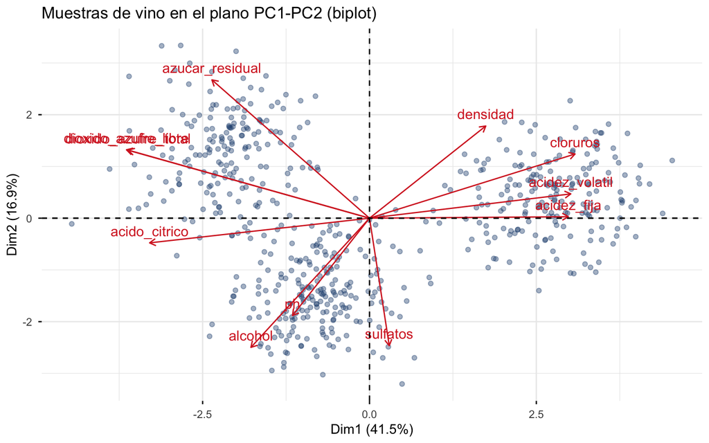

```r
# Proyección de las 600 muestras en el plano PC1-PC2 (biplot):
# los puntos son las muestras; las flechas son las variables. Variables con
# flechas casi paralelas están correlacionadas (esperamos ver juntas a las
# dos de dióxido de azufre).
fviz_pca_biplot(pca_vinos,
                label = "var", col.var = "#d62828",
                col.ind = "#1e4c7d", alpha.ind = 0.4,
                title = "Muestras de vino en el plano PC1-PC2 (biplot)")
```

## 3. ELECCIÓN DEL NÚMERO DE GRUPOS (k)

k-means necesita que fijemos k de antemano. Dos diagnósticos ayudan a elegirlo a partir de los datos (no a ojo).

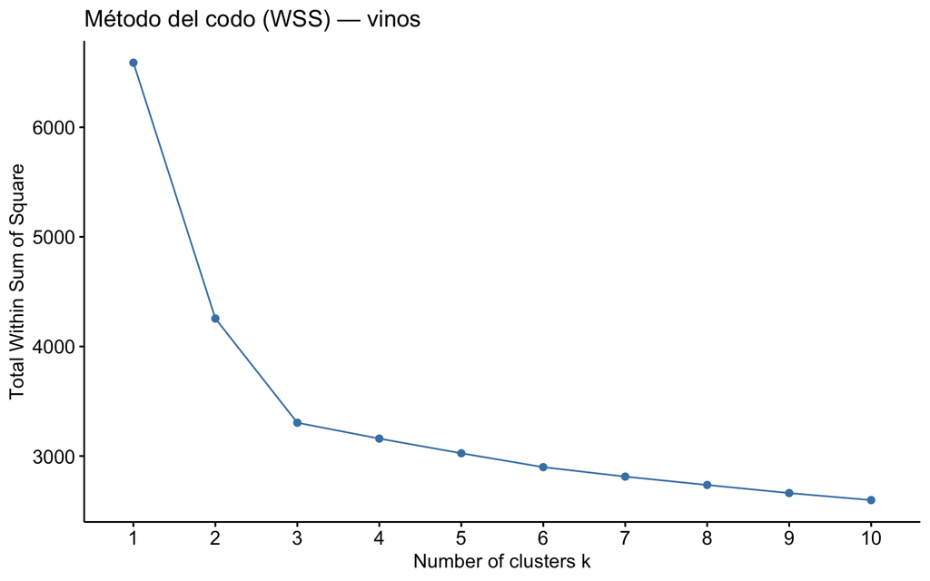

```r
# Método del codo (WSS = suma de cuadrados dentro de los grupos):
# al aumentar k, WSS siempre baja. Buscamos el "codo": el k a partir del
# cual el descenso se vuelve marginal. Ese codo sugiere el número de grupos.
set.seed(123)
fviz_nbclust(vinos_norm, kmeans, method = "wss", nstart = 20) +
  labs(title = "Método del codo (WSS) — vinos")
```

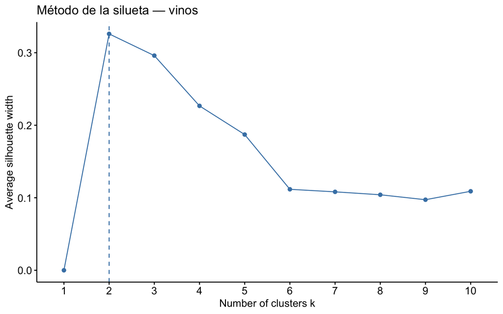

```r
# Método de la silueta: para cada k mide qué tan bien separados quedan los
# grupos (cada punto cómodo en su grupo vs. cercano a otro). El k con
# silueta promedio MÁS ALTA es el preferido. Suele ser el diagnóstico más
# decisivo cuando el codo es ambiguo.
set.seed(123)
fviz_nbclust(vinos_norm, kmeans, method = "silhouette", nstart = 20) +
  labs(title = "Método de la silueta — vinos")
```

```r
# Tras leer ambos diagnósticos, elegimos k = 3 para este dataset (el codo
# se aplana y la silueta es alta alrededor de 3 perfiles químicos).
k_elegido <- 3
```

## 4. K-MEANS CON EL k ELEGIDO

```r
#
# nstart = 25: k-means depende de la inicialización aleatoria de centroides;
# probar 25 arranques y quedarse con el mejor evita caer en un óptimo local
# malo. set.seed() garantiza reproducibilidad.
set.seed(123)
km_vinos <- kmeans(vinos_norm, centers = k_elegido, nstart = 25)
```

```r
# Tamaño de cada grupo.
km_vinos$size
```

```
[1] 180 202 218
```

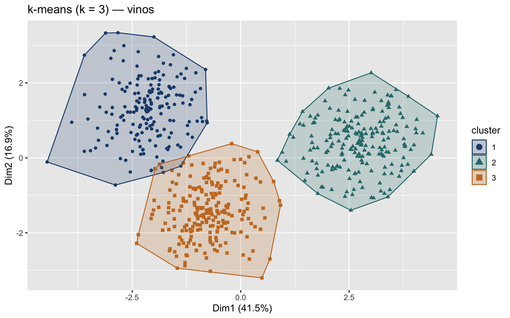

```r
# Visualización de los clusters (factoextra los proyecta sobre PC1-PC2).
fviz_cluster(km_vinos, data = vinos_norm,
             geom = "point", ellipse.type = "convex",
             palette = c("#1e4c7d", "#2d7a7a", "#c97b2a"),
             main = paste0("k-means (k = ", k_elegido, ") — vinos"))
```

```r
# PERFILADO DE LOS GRUPOS:
# Para interpretar QUÉ tipo de vino es cada grupo, calculamos las medias de
# las variables ORIGINALES (no las normalizadas) por cluster. Así leemos
# las cifras en sus unidades reales (% de alcohol, g/L, etc.).
vinos_perfilados <- vinos %>%
  mutate(cluster = factor(km_vinos$cluster))
```

```r
perfil_clusters <- vinos_perfilados %>%
  group_by(cluster) %>%
  summarise(across(everything(), mean), n = n()) %>%
  ungroup()
perfil_clusters
```

```
# A tibble: 3 × 13
  cluster acidez_fija acidez_volatil acido_citrico azucar_residual cloruros
  <fct>         <dbl>          <dbl>         <dbl>           <dbl>    <dbl>
1 1              6.60          0.277         0.406            7.76   0.0498
2 2              8.38          0.539         0.104            2.56   0.0847
3 3              6.97          0.304         0.365            2.07   0.0450
# ℹ 7 more variables: dioxido_azufre_libre <dbl>, dioxido_azufre_total <dbl>,
#   densidad <dbl>, ph <dbl>, sulfatos <dbl>, alcohol <dbl>, n <int>
```

INTERPRETACIÓN (leer ‘perfil_clusters’): Comparando las medias por grupo se identifica el carácter de cada perfil, por ejemplo:

- un grupo de vinos con alcohol alto y azúcar baja (más secos/potentes),
- un grupo con azúcar residual y dióxido de azufre altos (más dulces y conservados, típico de blancos),
- un grupo de acidez elevada y alcohol moderado (más frescos/ácidos). El alumno debe nombrar cada grupo según las medias reales observadas.

## 5. CLUSTERING JERÁRQUICO (comparación)

El clustering jerárquico no necesita fijar k de antemano: construye un árbol (dendrograma) fusionando puntos/grupos por cercanía. Lo “cortamos” a la altura que deje el número de grupos deseado.

```r
# Matriz de distancias euclidianas entre las 600 muestras normalizadas.
dist_vinos <- dist(vinos_norm, method = "euclidean")
```

```r
# hclust con Ward (ward.D2): tiende a formar grupos compactos y de tamaño
# parecido, lo que lo hace comparable con k-means.
hc_vinos <- hclust(dist_vinos, method = "ward.D2")
```

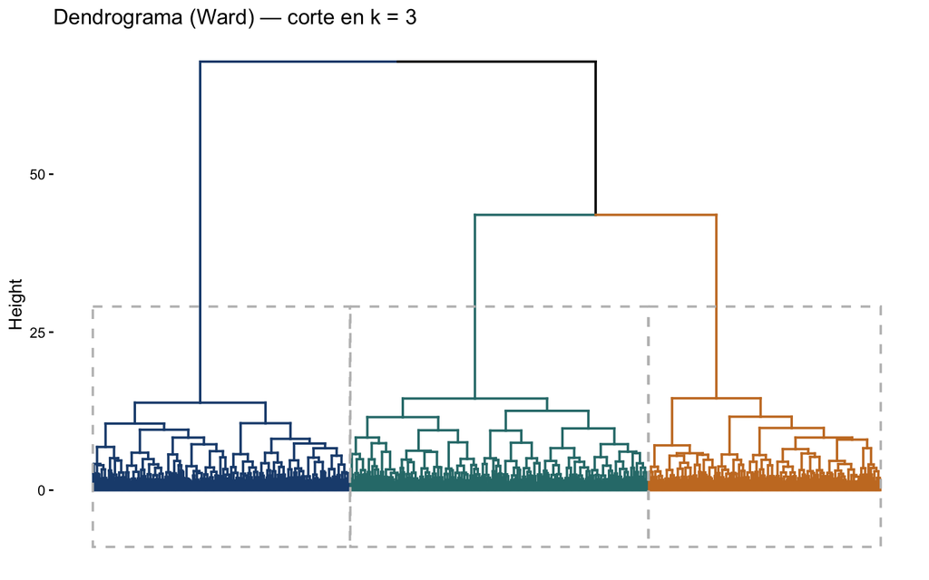

```r
# Dendrograma coloreado al mismo número de grupos que k-means.
fviz_dend(hc_vinos, k = k_elegido,
          k_colors = c("#1e4c7d", "#2d7a7a", "#c97b2a"),
          show_labels = FALSE, rect = TRUE,
          main = paste0("Dendrograma (Ward) — corte en k = ",
                        k_elegido))
```

```r
# Cortamos el árbol en k grupos.
grupos_hc <- cutree(hc_vinos, k = k_elegido)
```

```r
# COMPARACIÓN k-means vs jerárquico:
# La tabla cruzada muestra cuántas muestras coinciden entre ambos métodos.
# Las etiquetas de grupo son arbitrarias (el "1" de un método no tiene por
# qué ser el "1" del otro), así que NO miramos la diagonal sino si cada
# grupo de un método cae mayormente en UN solo grupo del otro: eso indica
# que ambos descubren la misma estructura, lo que da confianza en los
# perfiles encontrados.
table(kmeans = km_vinos$cluster, jerarquico = grupos_hc)
```

```
      jerarquico
kmeans   1   2   3
     1   3 177   0
     2   6   0 196
     3 218   0   0
```